# Heart Disease Indicators

Spencer Zeng

2022-12-06

## Introduction

### Background

Coronary heart disease occurs when plaque builds up, causing arteries to narrow and limiting the flow of oxygen-rich blood to the heart. It is common among U.S. population and can last for years or be lifelong.

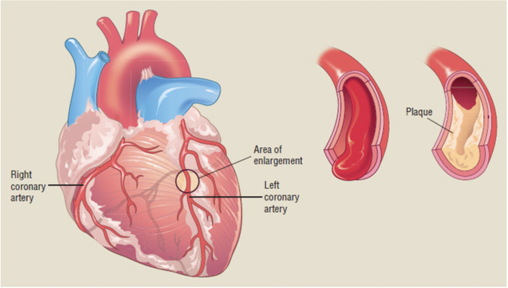

The Behavioral Risk Factor Surveillance System (BRFSS) is a program administered by CDC. Since 1984, BRFSS has been collecting data about U.S. residents regarding their physical and mental health, past and present health conditions, and access to healthcare. Each year, a standard survey questionnaire is developed that includes questions about : demographic information; current health perceptions, conditions, and behaviors; substance use; and diet.

In this project, I will be using BRFSS survey data in 2019.

### Aims

This project aims to predict whether a person is at risk for heart disease based on BRFSS survey data. Since the objective of BRFSS is to support monitoring and analyzing factors influencing public health in the U.S., it is of interest to examine if survey questions from BRFSS can be used for preventative health screening for heart disease.

## Loading Packages and Data

```r
set.seed(474)
library(tidyverse)
library(tidymodels)
library(corrplot)
library(dplyr)
library(ROSE)
library(xgboost)
library(kknn)
library(gridExtra)
setwd('/Users/zengspencer/pstat131')
```

```r
load("/Users/zengspencer/pstat131/brfss_raw.rda")
```

## Cleaning and Pre-processing

### Feature Selection

```r
dim(brfss_raw)
```

```
## [1] 418268    343
```

```r
# selected variable of interest
brfss_selected <- brfss_raw %>% select('CVDCRHD4', 'X_BMI5', 'SMOKE100', 'X_RFDRHV7','CVDSTRK3','MENTHLTH', 'PHYSHLTH','DIFFWALK','EXERANY2','DIABETE4','X_IMPRACE','X_AGEG5YR','BPHIGH4','TOLDHI2','CVDSTRK3','FRUIT2','FVGREEN1','INCOME2','SEXVAR')

# rename columns
brfss_selected <- brfss_selected %>% rename(
  'heart_disease' = 'CVDCRHD4',
  'bmi' = 'X_BMI5',
  'heavy_smoker' = 'SMOKE100',
  'heavy_alcohol' = 'X_RFDRHV7',
  'stroke' = 'CVDSTRK3',
  'mental_health' = 'MENTHLTH',
  'physical_health' = 'PHYSHLTH',
  'difficult_walk' = 'DIFFWALK',
  'exercise' = 'EXERANY2',
  'diabetes' = 'DIABETE4',
  'race' = 'X_IMPRACE',
  'age' = 'X_AGEG5YR',
  'high_bp' = 'BPHIGH4',
  'high_chol'= 'TOLDHI2',
  'stroke'='CVDSTRK3',
  'fruit' = 'FRUIT2',
  'veggies' = 'FVGREEN1',
  'income' = 'INCOME2',
  'sex' = 'SEXVAR'
)
```

### Missing Values

Below is a data frame of variables containing missing values. We can see bmi, veggies, fruit, high_chol, exercise, heavy_smoker, difficult_walk, and income have comparatively more missing values (greater than 100).

```r
# check for missing values
data.frame(brfss_selected %>%
  is.na() %>%
  colSums())
```

```
##                 brfss_selected.....is.na.......colSums..
## heart_disease                                          8
## bmi                                                36203
## heavy_smoker                                       15991
## heavy_alcohol                                          0
## stroke                                                11
## mental_health                                         19
## physical_health                                       32
## difficult_walk                                     13762
## exercise                                           20839
## diabetes                                               9
## race                                                   0
## age                                                    0
## high_bp                                                4
## high_chol                                          24443
## fruit                                              31052
## veggies                                            33075
## income                                              6881
## sex                                                    0
```

Since the data set is large with 418,268 observations in total, I’ll drop rows containing missing values.

```r
# drop missing values
brfss <- brfss_selected %>%
  drop_na()
```

We can see, after dropping, we still have 341,083 observations.

```r
dim(brfss)
```

```
## [1] 341083     18
```

When I checked the [code book](https://www.cdc.gov/brfss/annual_data/2019/pdf/codebook19_llcp-v2-508.HTML) provided by CDC, most categorical variables contain levels “don’t know” and “refused”. Since these levels do not provide useful information to my project, I’ll drop observations containing these levels.

```r
brfss <- brfss %>% subset(
  heart_disease != 7 & heart_disease !=9 & heavy_smoker != 7 & heavy_smoker != 9
  & heavy_alcohol != 7 & heavy_alcohol != 9 & stroke != 7 & stroke != 9 & mental_health != 77 & mental_health != 99
  & physical_health != 77 & physical_health != 99 & difficult_walk != 7 & difficult_walk != 9 &
  diabetes != 7 & diabetes != 9 & age != 14 & high_bp != 7 & high_bp != 9 & exercise != 7 &
  exercise != 9 & fruit != 777 & fruit != 999 & veggies != 777 & veggies != 999 & income !=
  77 & income != 99 & high_chol != 7 & high_chol != 9)

# convert to factors
  brfss <- brfss %>% mutate(
    heart_disease = factor(heart_disease,levels = c(1,2)),
    heavy_smoker = factor(heavy_smoker),
    heavy_alcohol = factor(heavy_alcohol),
    stroke = factor(stroke),
    mental_health = factor(mental_health),
    physical_health = factor(physical_health),
    exercise = factor(exercise),
    diabetes = factor(diabetes),
    race = factor(race),
    high_bp = factor(high_bp),
    high_chol = factor(high_chol),
    income = factor(income),
    sex = factor(sex))
```

And we are left with 263,841 observations

```r
dim(brfss)
```

```
## [1] 263841     18
```

### Balancing the Dataset

As we can see below, the response variable is highly imbalanced, with the percent of ratio of the number of respondents with heart disease to the number of respondents without heart disease being around 6.3%.

```r
summary(brfss$heart_disease)
```

```
##      1      2
##  15717 248124
```

Since the data set is still pretty large, I decided to balance it by undersampling, keeping all of the data in the minority class and randomly deleting observations in the majority class until there are equal number of observations in each class.

```r
# balance the data
brfss_balanced <- ovun.sample(heart_disease~., data=brfss, p=0.5, seed = 474,
method="under")$data
```

```r
dim(brfss_balanced)
```

```
## [1] 31394    18
```

## Dataset

Below is the table of variable description:

| Name | Variable Description | Type |
| --- | --- | --- |
| heart_disease | (Ever told) you had angina or coronary heart disease? | categorical |
| bmi | Body Mass Index | numeric |
| heavy_smoker | Have you smoked at least 100 cigarettes in your entire life? | categorical |
| heavy_alcohol | Heavy drinkers (adult men having more than 14 drinks per week and adult women having more than 7 drinks per week) | categorical |
| stroke | (Ever told) you had a stroke. | categorical |
| mental_health | For how many days during the past 30 days was your mental health not good? | categorical |
| physical_health | For how many days during the past 30 days was your physical health not good | categorical |
| difficult_walk | Do you have serious difficulty walking or climbing stairs? | categorical |
| exercise | During the past month, other than your regular job, did you participate in any physical activities or exercises? | categorical |
| diabetes | (Ever told) (you had) diabetes? | categorical |
| race | Race category | categorical |
| age | Fourteen-level age category | categorical |
| high_bp | (Ever told) (you had) high blood pressure? | categorical |
| high_chol | (Ever told) you had) high blood cholesterol? | categorical |
| fruit | Not including juices, how often did you eat fruit? | categorical |
| veggies | How often did you eat a green leafy or lettuce salad, with or without other vegetables? | categorical |
| income | Annual household income category | categorical |
| sex | Sex of respondent | categorical |

Below is the first six rows of the tidied dataset:

```r
head(brfss_balanced)
```

```
##   heart_disease  bmi heavy_smoker heavy_alcohol stroke mental_health
## 1             2 3859            1             1      2            15
## 2             2 2658            2             1      2            88
## 3             2 2193            2             1      2            88
## 4             2 2943            2             1      2            88
## 5             2 2995            1             1      2            30
## 6             2 3196            2             1      2            88
##   physical_health difficult_walk exercise diabetes race age high_bp high_chol
## 1              88              2        2        3    2   3       3         2
## 2              88              2        1        3    1  10       3         1
## 3              88              2        1        3    1  11       3         2
## 4              88              2        1        3    1  12       3         2
## 5               2              2        2        3    1   5       3         1
## 6               3              2        1        3    2  12       1         2
##   fruit veggies income sex
## 1   203     202      4   2
## 2   201     205      6   1
## 3   101     203      3   1
## 4   206     204      8   1
## 5   202     302      5   1
## 6   202     205      7   2
```

## Data Splitting

I’ll split the dataset into a training set and a testing set. The proportion of the training set to the whole dataset is 0.7.

```r
brfss_split <- brfss_balanced %>%
  initial_split(prop = 0.7, strata = "heart_disease")

brfss_train <- training(brfss_split)
brfss_test <- testing(brfss_split)
```

```r
dim(brfss_train)
```

```
## [1] 21974    18
```

```r
dim(brfss_test)
```

```
## [1] 9420   18
```

## Exploratory Data Analysis

Before model building, it’s of interest to explore correlations within our training set.

### Heart Disease

I’ll first plot a barplot of our response variable heart_disease.

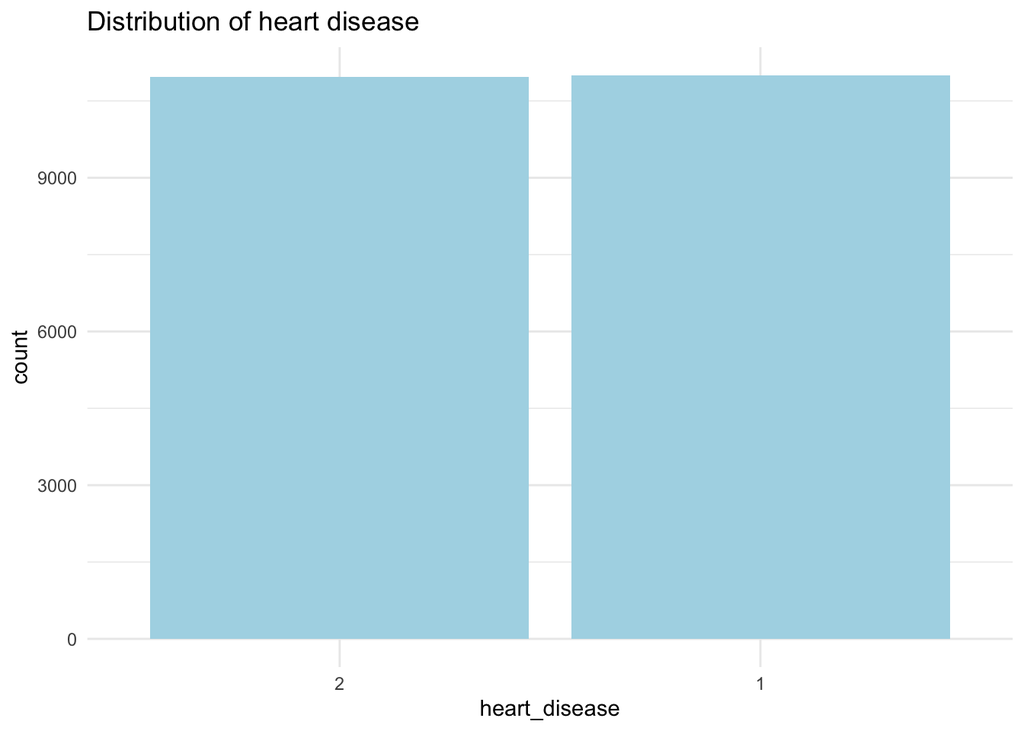

```r
brfss_train %>%
  ggplot(aes(x = heart_disease)) +
  geom_bar(fill='lightblue') +
  labs(title = 'Distribution of heart disease') +
  theme_minimal()
```

We can see there are equal number of observations in each class

### Demographic Risk Factors

I’ll explore the relationship between heart disease and demographic risk factors including age, sex, race, and income.

#### Sex

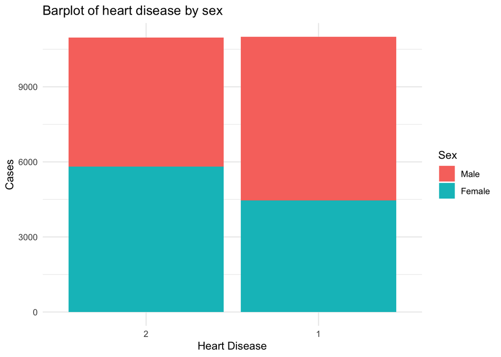

```r
plt_sex <-brfss_train %>%
  ggplot(aes(x = heart_disease, group = factor(sex) ,fill=factor(sex))) +
  geom_bar(position =  position_stack()) +
  labs(y = "Cases", x = "Heart Disease", title = 'Barplot of heart disease by sex') +
  scale_fill_discrete(labels=c('Male', 'Female')) +
  guides(fill=guide_legend(title="Sex")) +
  theme_minimal()

plt_sex
```

From this stacked barplot, we can see males are more prone to heart disease compared with females.

#### Race

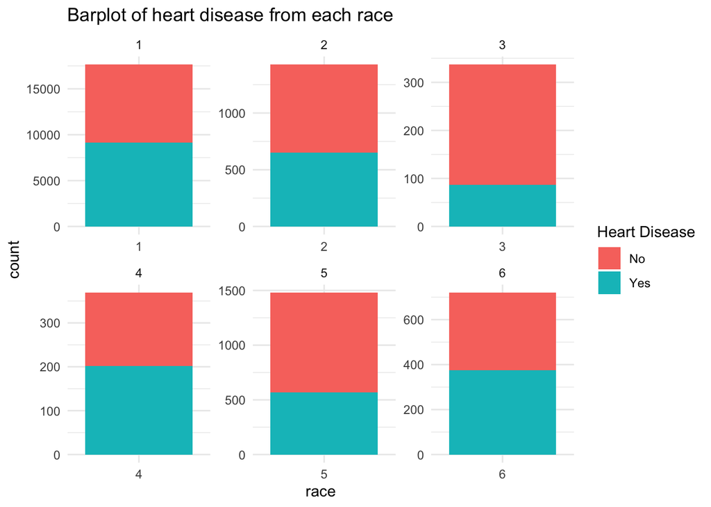

```r
plt_race <- brfss_train %>%
  ggplot(aes(x = race, group = factor(heart_disease) ,fill=factor(heart_disease))) +
  geom_bar(position = position_stack()) +
  facet_wrap(~race,scales = "free") +
  guides(fill=guide_legend(title="Heart Disease")) +
  scale_fill_discrete(labels=c('No', 'Yes')) +
  labs(title = 'Barplot of heart disease from each race ') +
  theme_minimal()




plt_race
```

#### Age

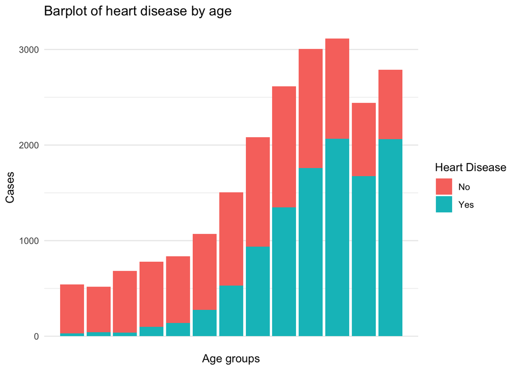

```r
plt_age <- brfss_train %>%
  ggplot(aes(x = age, group = factor(heart_disease) ,fill=factor(heart_disease))) +
  geom_bar(position = position_stack()) +
  scale_x_discrete(labels = c('18 to 24', '25 to 29', '30 to 34',
                              '35 to 39', '40 to 44', '45 to 49','50 to 59','60 to 64',
                              '65 to 69', '70 to 74', '75 to 79', '80+')) +

  guides(fill=guide_legend(title="Heart Disease")) +
  scale_fill_discrete(labels=c('No', 'Yes')) +
  labs(y = "Cases", x = "Age groups", title = 'Barplot of heart disease by age') +
  theme_minimal()

plt_age
```

In terms of age, the number of people having heart disease increases significantly as age increases.

#### Income

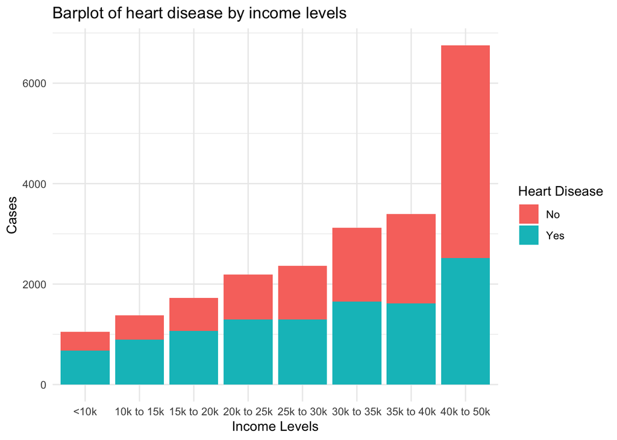

```r
plt_income <- brfss_train %>%
  ggplot(aes(x = income, group = factor(heart_disease) ,fill=factor(heart_disease))) +
  geom_bar(position = position_stack()) +
  scale_x_discrete(labels = c('<10k', '10k to 15k', '15k to 20k',
                              '20k to 25k', '25k to 30k', '30k to 35k',
                              '35k to 40k','40k to 50k',
                              '50k to 75k', '75k+')) +
  guides(fill=guide_legend(title='Heart Disease')) +
  scale_fill_discrete(labels=c('No', 'Yes')) +
  labs(y = "Cases", x = "Income Levels", title = 'Barplot of heart disease by income levels') +
  theme_minimal()

plt_income
```

When considering income, low income groups tend to be associated with a higher proportion of people getting heart disease.

### Behavioral Risk Factors

Below, I examine the relationship between heart disease and personal behaviors including heavy smoking, heavy alcohol consumption, mental health, physcial health, and bmi.

#### Mental health and physical health

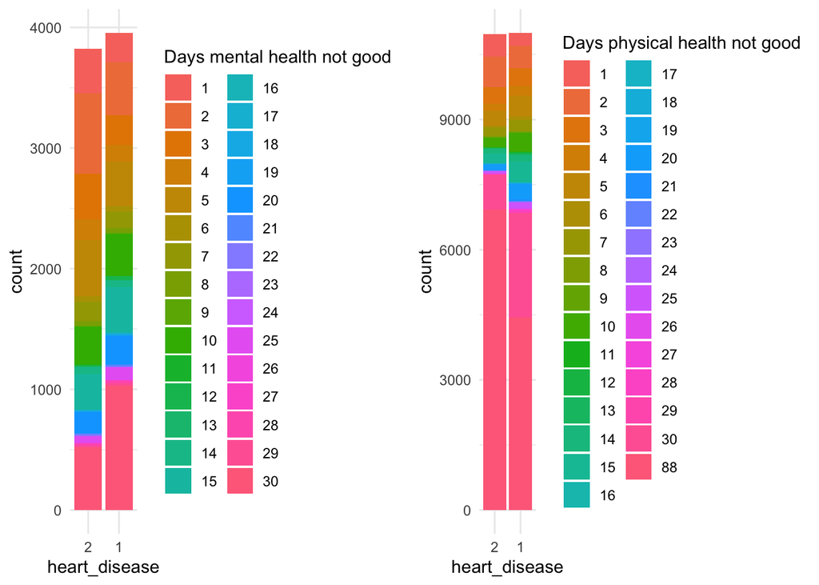

```r
mental_health <- brfss_train %>% subset (mental_health != 88)
plt_mh <- mental_health %>%
  ggplot(aes(x = heart_disease, group = factor(mental_health) ,fill=factor(mental_health))) +
  geom_bar(position = position_stack()) +
  guides(fill=guide_legend(title="Days mental health not good")) +
  theme_minimal()


plt_ph <- brfss_train %>%
  ggplot(aes(x = heart_disease, group = factor(physical_health) ,fill=factor(physical_health))) + geom_bar(position = position_stack()) +
  guides(fill=guide_legend(title="Days physical health not good")) +
  theme_minimal()

grid.arrange(plt_mh, plt_ph, ncol = 2)
```

In terms of mental health, the number of people having poor mental health over 20 days are higher among those with heart diseases; meanwhile, the number of people having no physical health issues during the past month is higher among those without heart diseases.

#### Heavy smoking

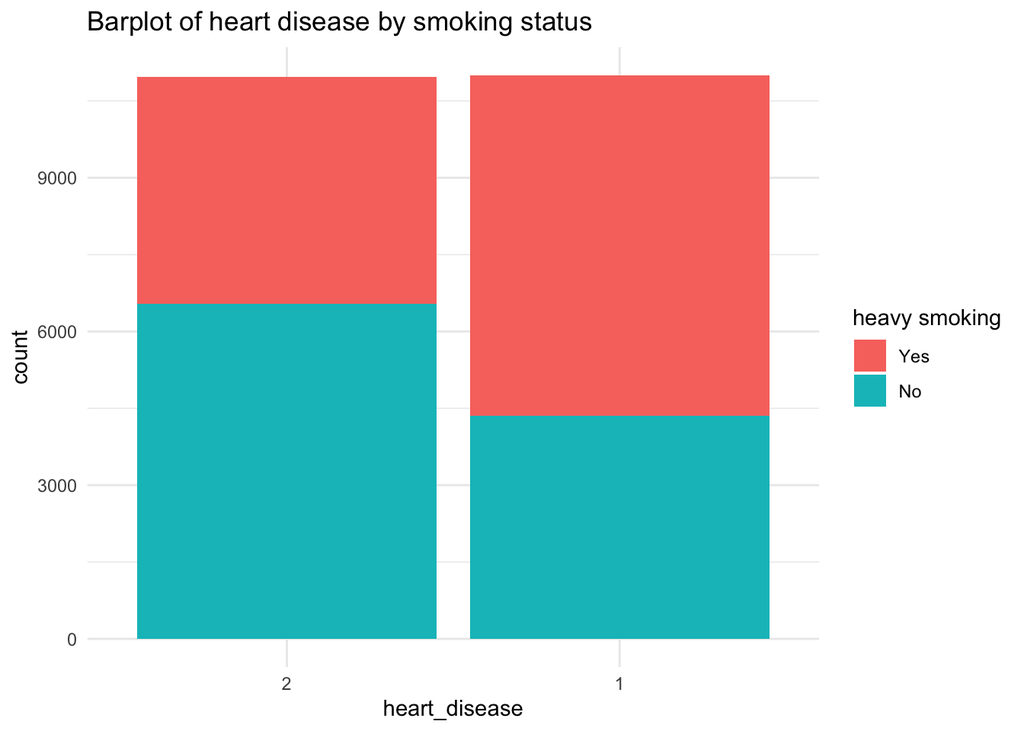

```r
brfss_train %>%
  ggplot(aes(x = heart_disease, group = factor(heavy_smoker) ,fill=factor(heavy_smoker))) +
  geom_bar(position = position_stack()) +
  guides(fill=guide_legend(title="heavy smoking")) +
  scale_fill_discrete(labels=c('Yes', 'No')) +
  labs(title = 'Barplot of heart disease by smoking status') +
  theme_minimal()
```

The barplot of heart disease by heavy_smoker shows that people with heart disease smokes significantly more frequently compared with those without .

#### heavy alcohol consumption

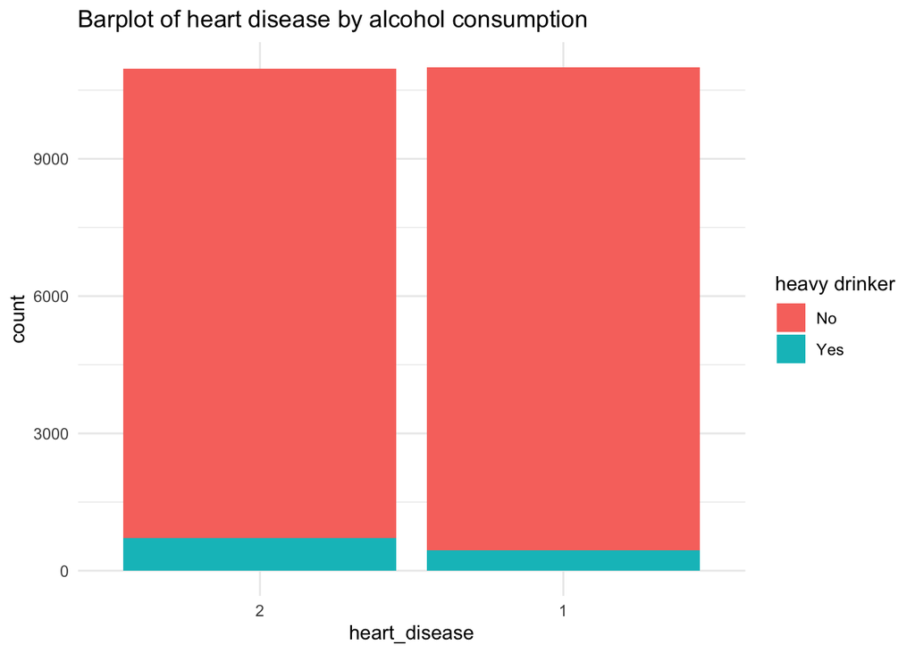

```r
brfss_train %>%
  ggplot(aes(x = heart_disease, group = factor(heavy_alcohol) ,fill=factor(heavy_alcohol))) +
  geom_bar(position = position_stack()) +
  guides(fill=guide_legend(title="heavy drinker")) +
  scale_fill_discrete(labels=c('No', 'Yes')) +
  labs(title = 'Barplot of heart disease by alcohol consumption') +
  theme_minimal()
```

Surprisingly, heavy alcohol consumption does not seem to significantly differe between those with heart diseases and those without.

#### BMI

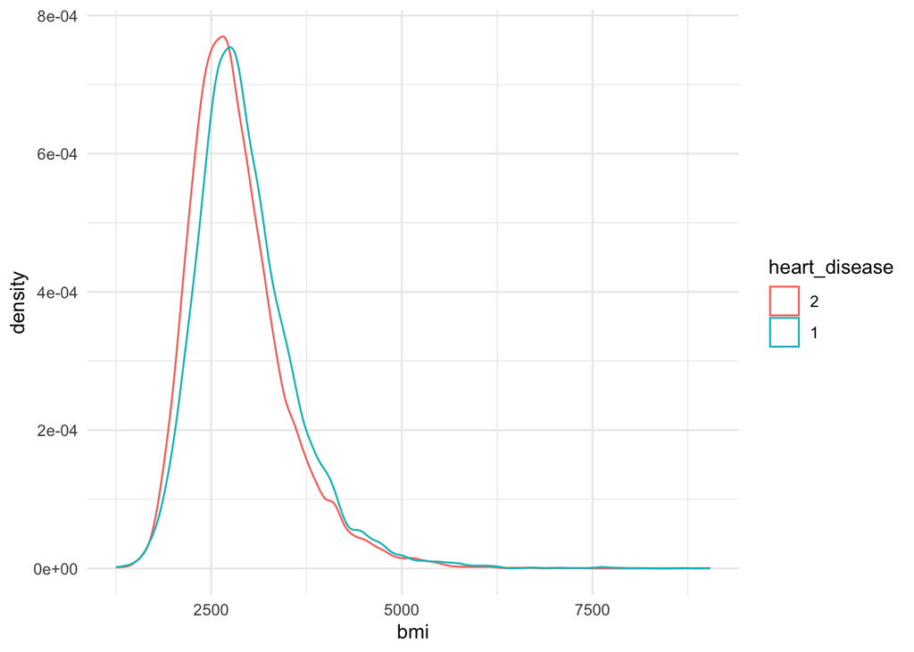

```r
ggplot(brfss_train, aes(x=bmi, color=heart_disease)) +
  geom_density() +
  theme_minimal()
```

The density curve of bmi by heart disease shows that people with having heart disease tends to have higher weight.

## Model Building

#### Setting up recipe

I’ll set up a recipe to predict instances of heart disease, dummy coding categorical variables and normalizing all numerical variables.

```r
brfss_recipe <- recipe(heart_disease ~., data = brfss_train) %>%
  step_dummy(all_nominal_predictors()) %>%
  step_center(all_numeric_predictors()) %>%
  step_scale(all_numeric_predictors())
```

#### Creating folds

I’ll randomly divides the training set into 5 groups of approximately equal size. Since I have already balanced the dataset before, I’ll not stratify the folds by response variable. These folds will be used for cross-validation, during which 1 fold will be used for assessment and the remaining 4 folds will be used for for analysis. This process will repeat 5 times, and a different validation set will be used each time.

```r
brfss_folds <- vfold_cv(brfss_train, v = 5)
```

### Elastic Net

```r
# set up model and workflow
elastic_net_spec <- multinom_reg(penalty = tune(),
                                 mixture = tune()) %>%
  set_mode("classification") %>%
  set_engine("glmnet")

en_workflow <- workflow() %>%
  add_recipe(brfss_recipe) %>%
  add_model(elastic_net_spec)

# create a regular grid
en_grid <- grid_regular(penalty(range = c(-5, 5)),
                        mixture(range = c(0, 1)), levels = 5)
```

```r
# fit on training set
tune_res_en <- tune_grid(
  en_workflow,
  resamples = brfss_folds,
  grid = en_grid
)
```

After fitting models on the training set, I’ll select the model with the highest roc_auc and save the result to an RDA file for future model evaluation

```r
# select the best model
best_model_en <- select_best(tune_res_en, metric = "roc_auc")

en_final <- finalize_workflow(en_workflow, best_model_en)

en_final_fit <- fit(en_final, data = brfss_train)
```

```r
save(tune_res_en, en_final_fit, en_workflow,best_model_en, file = "/Users/zengspencer/pstat131/en.rda")
```

### K Nearest Neighbors

I’ll be fitting a k nearest neighbors, tuning the number of neighbors with 5 levels.

```r
# set up model and workflow
knn_spec <-
  nearest_neighbor(neighbors = tune()) %>%
  set_mode("classification") %>%
  set_engine("kknn")

# create grid
knn_workflow <- workflow() %>%
  add_model(knn_spec) %>%
  add_recipe(brfss_recipe)

# create a regular grid
knn_grid <- grid_regular(neighbors(range = c(1, 10)), levels = 5)
```

```r
# fit on training set
tune_res_knn <- tune_grid(
  knn_workflow,
  resamples = brfss_folds,
  grid = knn_grid
)
```

Similar to previous model, I’ll select and save the best model to an RDA fille.

```r
# select the best model
best_model_knn <- select_best(tune_res_knn, metric = "roc_auc")

knn_final <- finalize_workflow(knn_workflow, best_model_knn)

knn_final_fit <- fit(knn_final, data = brfss_train)
```

```r
save(tune_res_knn,knn_final_fit, knn_workflow, best_model_knn, file = "/Users/zengspencer/pstat131/knn.rda")
```

### Random Forest

I’ll be fitting a random forest, tuning trees, mtry (the number of randomly selected predictors), and min_n (minimal node size) with 5 levels each.

```r
# set up model and workflow
rf_spec<-rand_forest() %>%
  set_engine("ranger",importance="impurity")%>%
  set_mode("classification")

rf_wf<-workflow()%>%
  add_model(rf_spec %>% set_args(mtry=tune(),trees=tune(),min_n=tune()))%>%
  add_formula(heart_disease~.)

# create grid
rf_grid <-grid_regular(
  mtry(range= c(1,17)),
  trees(range = c(50,200)),
min_n(range = c(10,30)),
  levels = 5)
```

```r
# fit on training set
tune_res_rf <-tune_grid(
  rf_wf,
  resample = brfss_folds,
  grid = rf_grid,
  metrics = metric_set(roc_auc)
)
```

After fitting models on the training set, I’ll select the model with the highest roc_auc and save the result to an RDA file for future model evaluation

```r
# select the best model
best_model_rf <- select_best(tune_res_rf, metric = "roc_auc")

rf_final <- finalize_workflow(rf_wf, best_model_rf)

rf_final_fit <- fit(rf_final, data = brfss_train)
```

```r
save(tune_res_rf,rf_final_fit, rf_wf, best_model_rf, file = "/Users/zengspencer/pstat131/rf.rda")
```

### Boosted Tree

```r
# set up model and workflow

boost_spec<-boost_tree()%>%
  set_engine("xgboost")%>%
  set_mode("classification")

boost_wf<-workflow()%>%
  add_model(boost_spec %>% set_args(
    learn_rate = tune(),
    trees = tune())) %>%
  add_formula(heart_disease~.)

# create a grid
boost_grid <- grid_regular(
  learn_rate(range = c(0.005,0.5)),
  trees(range = c(10,1000)),
  levels = 5)
```

```r
# fit on training set
tune_res_boost <-tune_grid(
  boost_wf,
  resample = brfss_folds,
  grid = boost_grid,
  metrics = metric_set(roc_auc)
)
```

After fitting models on the training set, I’ll select the model with the highest roc_auc and save the result to an RDA file for future model evaluation

```r
# select the best model
best_model_boost <- select_best(tune_res_boost, metric = "roc_auc")

boost_final <- finalize_workflow(boost_wf, best_model_boost)

boost_final_fit <- fit(boost_final, data = brfss_train)
```

```r
# save result
save(tune_res_boost,boost_final_fit, boost_wf, best_model_boost,file = "/Users/zengspencer/pstat131/boost.rda")
```

## Model Evaluation

```r
# loading stored results
load("/Users/zengspencer/pstat131/boost.rda")
load("/Users/zengspencer/pstat131/rf.rda")
load("/Users/zengspencer/pstat131/knn.rda")
load("/Users/zengspencer/pstat131/en.rda")
```

### Elastic net

The autoplot of result shows that smaller values of mixture (proportion of lasso penalty) and smaller values of mixture (amount of regularization) leads to higher accuracy and roc_auc.

[figure not shown]

```r
autoplot(tune_res_en)
```

### K nearest neighbors

The autoplot of knn model shows that model performance increases as the number of neighbors increases.

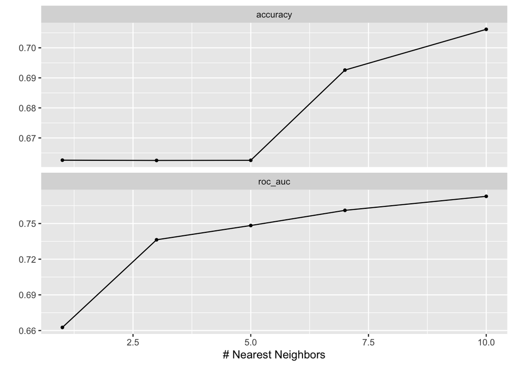

```r
autoplot(tune_res_knn)
```

### Random forest

The autoplot of random forest shows that the model perform best when the minimal node size and the number of trees are relatively large, and the number of predictors is relatively small.

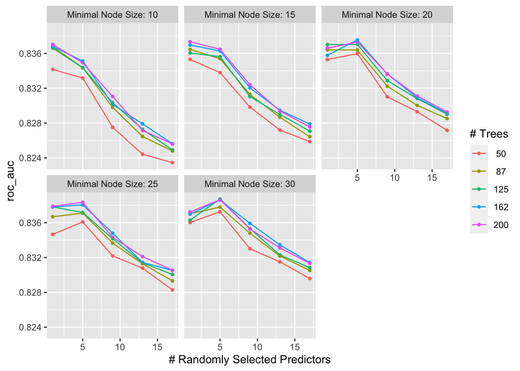

```r
autoplot(tune_res_rf)
```

### Boosted tree

The autoplot of boosted tree shows that model perform best when the learning rate and the number of trees are small.

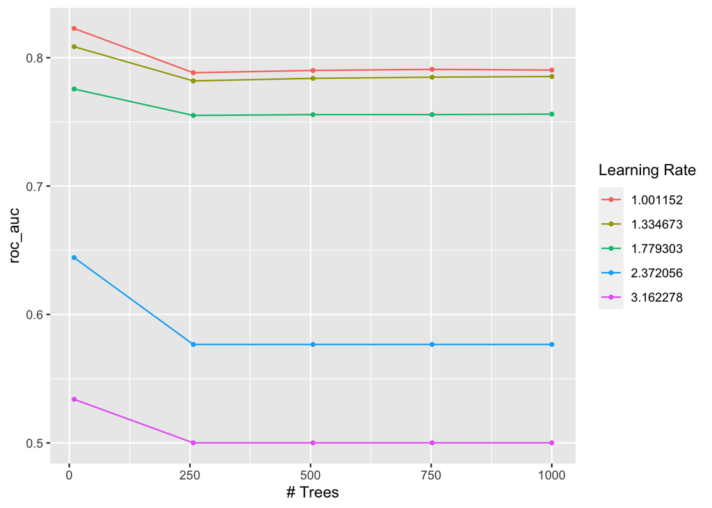

```r
autoplot(tune_res_boost)
```

## Comparing model performances

Comparison of model accuracy shows that knn has the highest accuracy.

```r
en_acc <- augment(en_final_fit, new_data = brfss_train) %>%
  accuracy(truth = heart_disease, estimate = .pred_class)

knn_acc <- augment(knn_final_fit, new_data = brfss_train) %>%
  accuracy(truth = heart_disease, estimate = .pred_class)

rf_acc <- augment(rf_final_fit, new_data = brfss_train) %>%
  accuracy(truth = heart_disease, estimate = .pred_class)

boost_acc <- augment(boost_final_fit, new_data = brfss_train) %>%
  accuracy(truth = heart_disease, estimate = .pred_class)


accuracies <- c(en_acc$.estimate, knn_acc$.estimate,
                rf_acc$.estimate, boost_acc$.estimate)
models <- c("elastic net", "knn", "random forest", "boosted tree")

results <- tibble(accuracies = accuracies, models = models)
results %>%
  arrange(-accuracies)
```

```
## # A tibble: 4 × 2
##   accuracies models
##        <dbl> <chr>
## 1      0.883 knn
## 2      0.830 random forest
## 3      0.794 boosted tree
## 4      0.767 elastic net
```

## Model performance on testing set

I’ll be fitting the knn model with 10 neighbors.

```r
load("/Users/zengspencer/pstat131/best_fit_knn.rda")
```

#### ROC curve

The roc curve is to the up left corner of the plot panel.

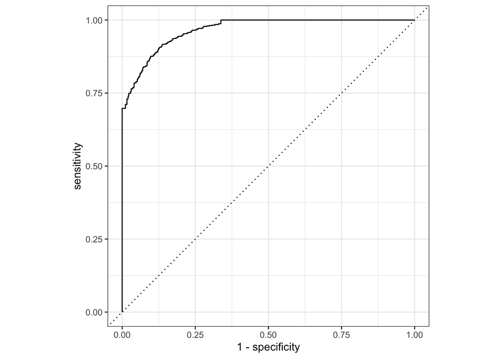

```r
options(yardstick.event_first = FALSE)

# roc curve
augment(best_fit_knn, new_data = brfss_test) %>%
  roc_curve(heart_disease, .pred_1) %>%
  autoplot()
```

#### roc_auc

```r
options(yardstick.event_first = FALSE)
augment(best_fit_knn, new_data = brfss_test) %>%
  roc_auc(heart_disease, estimate = .pred_1) %>%
  select(.estimate)
```

```
## # A tibble: 1 × 1
##   .estimate
##       <dbl>
## 1     0.966
```

#### confusion matrix

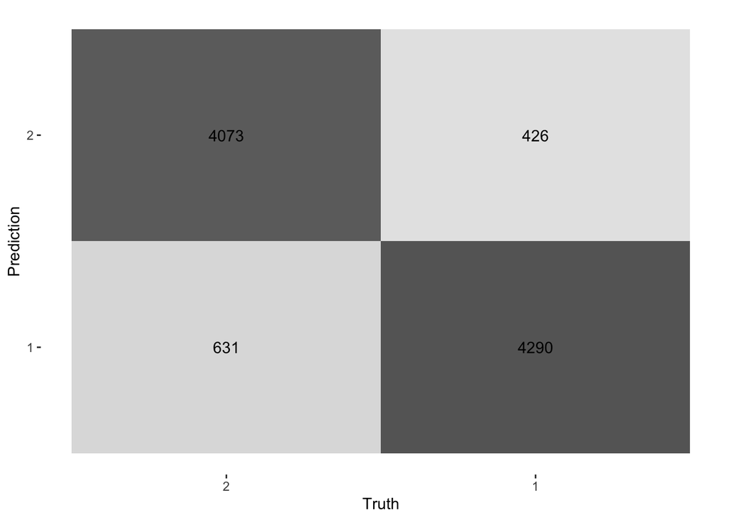

```r
options(yardstick.event_first = FALSE)
augment(best_fit_knn, brfss_test) %>%
  conf_mat(truth = heart_disease, estimate = .pred_class) %>%
  autoplot(type="heatmap")
```

## Conclusion

In conclusion, k nearest neighbors performed the best while elastic net performed the worst. I’m a little bit surprised that random forest performed worse than knn. Overall, the result suggests that BRFSS’s survey questions BRFSS is good for preventative health screening and monitoring heart disease. In terms of future analysis, it may be useful to reexamine the technique used to balance the dataset and choose another one (i.e. oversampling) to see if model performance can be improved if computing power supports. Also, rather than performing feature selection based on literature review, I might try feature extraction to see if some other indicators are ignored.